# IODS course project

### Standardize the dataset

Scaling the data

```r
# center and standardize variables
boston_scaled <- scale(Boston)

boston_scaled <- as.data.frame(boston_scaled)

# summaries of the scaled variables
summary(boston_scaled)
```

```
##       crim                 zn               indus
##  Min.   :-0.419367   Min.   :-0.48724   Min.   :-1.5563
##  1st Qu.:-0.410563   1st Qu.:-0.48724   1st Qu.:-0.8668
##  Median :-0.390280   Median :-0.48724   Median :-0.2109
##  Mean   : 0.000000   Mean   : 0.00000   Mean   : 0.0000
##  3rd Qu.: 0.007389   3rd Qu.: 0.04872   3rd Qu.: 1.0150
##  Max.   : 9.924110   Max.   : 3.80047   Max.   : 2.4202
##       chas              nox                rm               age
##  Min.   :-0.2723   Min.   :-1.4644   Min.   :-3.8764   Min.   :-2.3331
##  1st Qu.:-0.2723   1st Qu.:-0.9121   1st Qu.:-0.5681   1st Qu.:-0.8366
##  Median :-0.2723   Median :-0.1441   Median :-0.1084   Median : 0.3171
##  Mean   : 0.0000   Mean   : 0.0000   Mean   : 0.0000   Mean   : 0.0000
##  3rd Qu.:-0.2723   3rd Qu.: 0.5981   3rd Qu.: 0.4823   3rd Qu.: 0.9059
##  Max.   : 3.6648   Max.   : 2.7296   Max.   : 3.5515   Max.   : 1.1164
##       dis               rad               tax             ptratio
##  Min.   :-1.2658   Min.   :-0.9819   Min.   :-1.3127   Min.   :-2.7047
##  1st Qu.:-0.8049   1st Qu.:-0.6373   1st Qu.:-0.7668   1st Qu.:-0.4876
##  Median :-0.2790   Median :-0.5225   Median :-0.4642   Median : 0.2746
##  Mean   : 0.0000   Mean   : 0.0000   Mean   : 0.0000   Mean   : 0.0000
##  3rd Qu.: 0.6617   3rd Qu.: 1.6596   3rd Qu.: 1.5294   3rd Qu.: 0.8058
##  Max.   : 3.9566   Max.   : 1.6596   Max.   : 1.7964   Max.   : 1.6372
##      black             lstat              medv
##  Min.   :-3.9033   Min.   :-1.5296   Min.   :-1.9063
##  1st Qu.: 0.2049   1st Qu.:-0.7986   1st Qu.:-0.5989
##  Median : 0.3808   Median :-0.1811   Median :-0.1449
##  Mean   : 0.0000   Mean   : 0.0000   Mean   : 0.0000
##  3rd Qu.: 0.4332   3rd Qu.: 0.6024   3rd Qu.: 0.2683
##  Max.   : 0.4406   Max.   : 3.5453   Max.   : 2.9865
```

Create cathegorical values:

```r
# create a quantile vector of crim and print it
bins <- quantile(boston_scaled$crim)
bins
```

```
##           0%          25%          50%          75%         100%
## -0.419366929 -0.410563278 -0.390280295  0.007389247  9.924109610
```

```r
# create a categorical variable 'crime'
crime <- cut(boston_scaled$crim, breaks = bins, include.lowest = TRUE, label = c("low", "med_low", "med_high", "high"))

table(crime)
```

```
## crime
##      low  med_low med_high     high
##      127      126      126      127
```

```r
# remove original crim from the dataset
boston_scaled <- dplyr::select(boston_scaled, -crim)

# add the new categorical value to scaled data
boston_scaled <- data.frame(boston_scaled, crime)
```

Splitting to train and test sets

```r
# number of rows in the Boston dataset
n <- nrow(Boston)

# choose randomly 80% of the rows
ind <- sample(n,  size = n * 0.8)

# create train set
train <- boston_scaled[ind,]

# create test set
test <- boston_scaled[-ind,]
```

### Fitting the LDA model

```r
# linear discriminant analysis
lda.fit <- lda(crime ~ ., data = train)

# print the lda.fit object
lda.fit
```

```
## Call:
## lda(crime ~ ., data = train)
##
## Prior probabilities of groups:
##       low   med_low  med_high      high
## 0.2623762 0.2475248 0.2425743 0.2475248
##
## Group means:
##                   zn      indus        chas        nox          rm
## low       0.99262777 -0.9132988 -0.08661679 -0.8716638  0.43598122
## med_low  -0.05804005 -0.3233039 -0.03610305 -0.5867831 -0.09839553
## med_high -0.36298400  0.2140749  0.12941585  0.4285733  0.17250127
## high     -0.48724019  1.0171519 -0.03610305  1.0452828 -0.40785283
##                 age        dis        rad        tax    ptratio
## low      -0.9173398  0.9053499 -0.6936710 -0.7473936 -0.4370085
## med_low  -0.4463023  0.3871603 -0.5466022 -0.4892522 -0.1189562
## med_high  0.4196565 -0.3891376 -0.4052939 -0.2892381 -0.3240044
## high      0.7963768 -0.8523147  1.6377820  1.5138081  0.7803736
##                black        lstat        medv
## low       0.38107009 -0.780121194  0.53915918
## med_low   0.31605139 -0.176439209  0.02698607
## med_high  0.07862334 -0.001272031  0.21955112
## high     -0.88641494  0.912432521 -0.71248583
##
## Coefficients of linear discriminants:
##                 LD1          LD2         LD3
## zn       0.10112195  0.628847803 -1.04338916
## indus    0.03527185 -0.265099500  0.26321335
## chas    -0.08232003  0.004659491  0.14489030
## nox      0.37140001 -0.783351260 -1.29362669
## rm      -0.06194324 -0.140298889 -0.08339717
## age      0.26796898 -0.296665527 -0.26387004
## dis     -0.06044157 -0.265974913  0.15487669
## rad      3.15694153  1.077897749 -0.22082716
## tax      0.03227425 -0.163151100  0.69933451
## ptratio  0.13084786  0.035950697 -0.38334543
## black   -0.12980814  0.008077308  0.12107625
## lstat    0.26565328 -0.252249250  0.46600958
## medv     0.21724505 -0.427043612 -0.20068138
##
## Proportion of trace:
##    LD1    LD2    LD3
## 0.9483 0.0380 0.0137
```

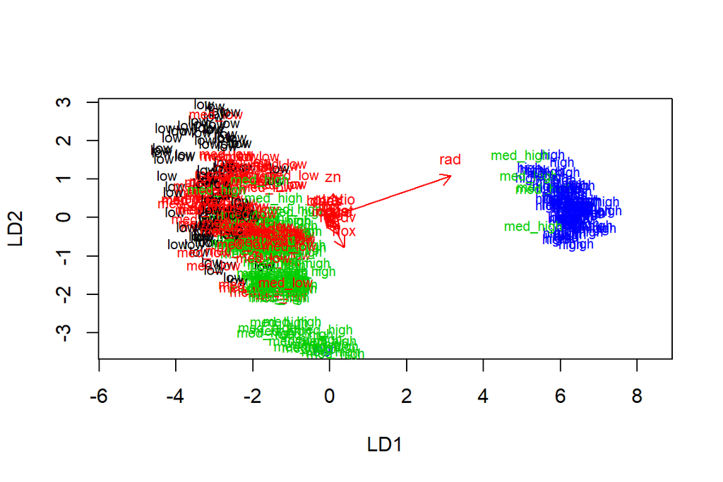

```r
# the function for lda biplot arrows
lda.arrows <- function(x, myscale = 1, arrow_heads = 0.1, color = "red", tex = 0.75, choices = c(1,2)){
  heads <- coef(x)
  arrows(x0 = 0, y0 = 0,
         x1 = myscale * heads[,choices[1]],
         y1 = myscale * heads[,choices[2]], col=color, length = arrow_heads)
  text(myscale * heads[,choices], labels = row.names(heads),
       cex = tex, col=color, pos=3)
}

# target classes as numeric
classes <- as.numeric(train$crime)

# plot the lda results
plot(lda.fit, col = classes, pch = classes, dimen = 2)
lda.arrows(lda.fit, myscale = 1)
```

We can see distinct groups of crime rate categories with some overlap

### Predicting the classes and cross tabulation

```r
# save the correct classes from test data
correct_classes <- test$crime

# remove the crime variable from test data
test <- dplyr::select(test, -crime)

# predict classes with test data
lda.pred <- predict(lda.fit, newdata = test)

# cross tabulate the results
table(correct = correct_classes, predicted = lda.pred$class)
```

```
##           predicted
## correct    low med_low med_high high
##   low       13       7        1    0
##   med_low    4      15        7    0
##   med_high   0      12       15    1
##   high       0       0        0   27
```

Overall accuracy of predictions:

```r
mean(lda.pred$class==correct_classes)
```

```
## [1] 0.6862745
```

# Chapter 5: Dimensionality reduction techniques

### Loading and checking the structure of the data

```r
# access libraries
library(MASS)
library(dplyr)
library(tidyr)
library(corrplot)
library(ggplot2)
library(GGally)
library(FactoMineR)
```

```r
# load the human data
human <- read.csv("~/IODS-project/data/human.csv")

# explore the dataset
str(human)
```

```
## 'data.frame':    155 obs. of  9 variables:
##  $ X        : Factor w/ 155 levels "Afghanistan",..: 105 6 134 41 101 54 67 149 28 102 ...
##  $ Edu2.FM  : num  1.007 0.997 0.983 0.989 0.969 ...
##  $ Labo.FM  : num  0.891 0.819 0.825 0.884 0.829 ...
##  $ Life.Exp : num  81.6 82.4 83 80.2 81.6 80.9 80.9 79.1 82 81.8 ...
##  $ Edu.Exp  : num  17.5 20.2 15.8 18.7 17.9 16.5 18.6 16.5 15.9 19.2 ...
##  $ GNI      : int  64992 42261 56431 44025 45435 43919 39568 52947 42155 32689 ...
##  $ Mat.Mor  : int  4 6 6 5 6 7 9 28 11 8 ...
##  $ Ado.Birth: num  7.8 12.1 1.9 5.1 6.2 3.8 8.2 31 14.5 25.3 ...
##  $ Parli.F  : num  39.6 30.5 28.5 38 36.9 36.9 19.9 19.4 28.2 31.4 ...
```

```r
summary(human)
```

```
##            X          Edu2.FM          Labo.FM          Life.Exp
##  Afghanistan:  1   Min.   :0.1717   Min.   :0.1857   Min.   :49.00
##  Albania    :  1   1st Qu.:0.7264   1st Qu.:0.5984   1st Qu.:66.30
##  Algeria    :  1   Median :0.9375   Median :0.7535   Median :74.20
##  Argentina  :  1   Mean   :0.8529   Mean   :0.7074   Mean   :71.65
##  Armenia    :  1   3rd Qu.:0.9968   3rd Qu.:0.8535   3rd Qu.:77.25
##  Australia  :  1   Max.   :1.4967   Max.   :1.0380   Max.   :83.50
##  (Other)    :149
##     Edu.Exp           GNI            Mat.Mor         Ado.Birth
##  Min.   : 5.40   Min.   :   581   Min.   :   1.0   Min.   :  0.60
##  1st Qu.:11.25   1st Qu.:  4198   1st Qu.:  11.5   1st Qu.: 12.65
##  Median :13.50   Median : 12040   Median :  49.0   Median : 33.60
##  Mean   :13.18   Mean   : 17628   Mean   : 149.1   Mean   : 47.16
##  3rd Qu.:15.20   3rd Qu.: 24512   3rd Qu.: 190.0   3rd Qu.: 71.95
##  Max.   :20.20   Max.   :123124   Max.   :1100.0   Max.   :204.80
##
##     Parli.F
##  Min.   : 0.00
##  1st Qu.:12.40
##  Median :19.30
##  Mean   :20.91
##  3rd Qu.:27.95
##  Max.   :57.50
##
```

The dataset combines several indicators from most countries in the world. It has 155 observations with 9 variables.

### Graphical overview of the data

Plot the distributions and correlations of the variables:

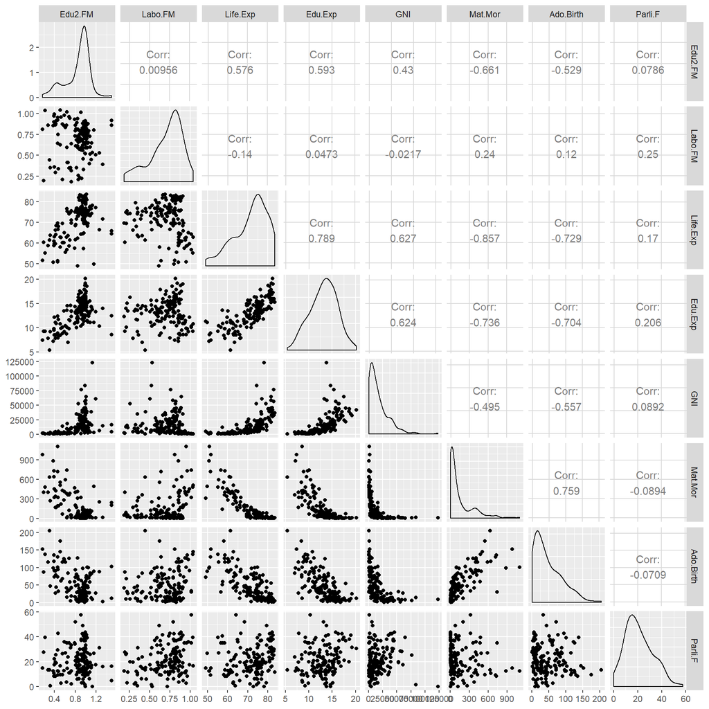

```r
# for visualizations, take the data without the name column
human_ <- human[-1]

# visualize the 'human_' variables
ggpairs(human_)
```

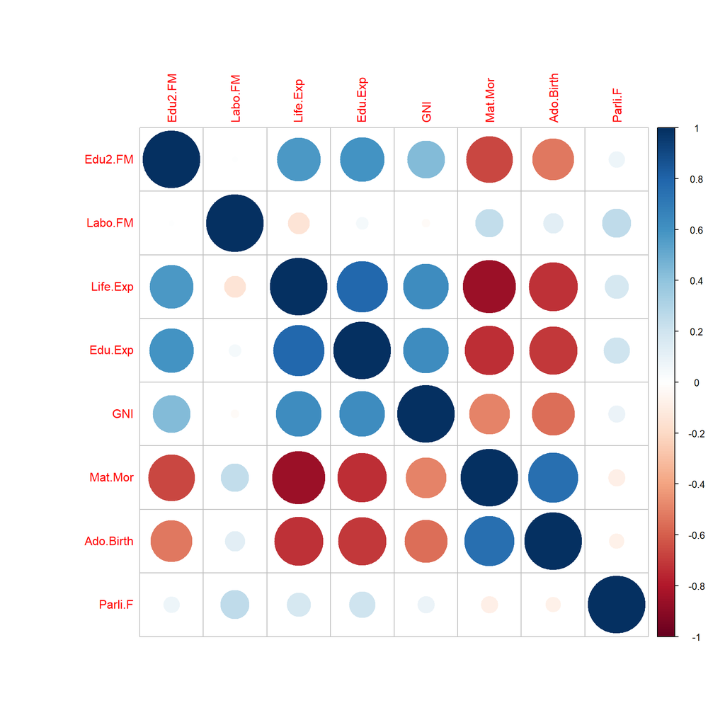

```r
# compute the correlation matrix and visualize it with corrplot
cor(human_) %>% corrplot()
```

From the distribution of GNI we see that the majority of countries are quite poor. GNI seems to be positively correlated with Life expectancy at birth and Expected years of schooling. It’s negatively correlated with Maternal mortality ratio and Adolescent birth rate. The are somewhat expected observations.

### Principal component analysis

Non-standardized

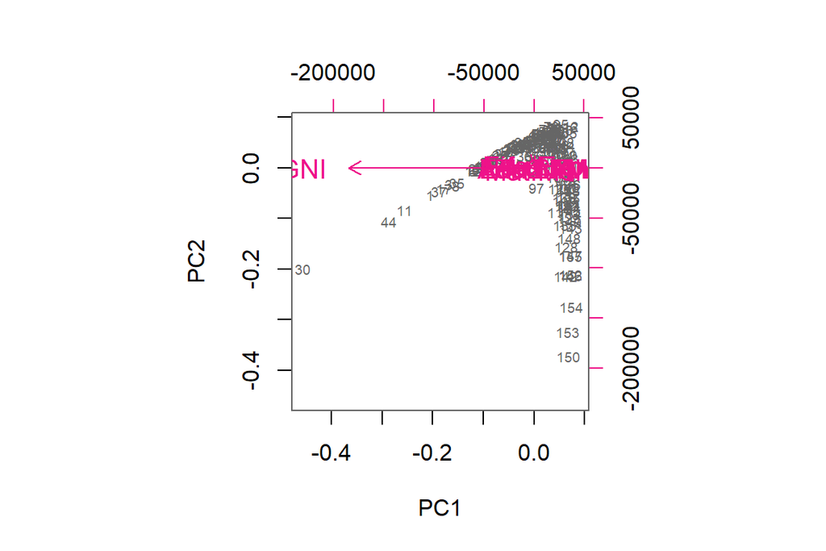

```r
# perform principal component analysis (with the SVD method)
pca_human <- prcomp(human_)

# draw a biplot of the principal component representation and the original variables
biplot(pca_human, choices = 1:2, cex = c(0.6, 1.2), col = c("grey40", "deeppink2"))
```

PCA is sensitive to the relative scaling of the original features. It assumes variables with larger variance to be more important. For this reason, the GNI value is basically the only one popping out from the plot.

Standardized

```r
# standardize the variables
human_std <- scale(human_)

# create and print out a summary of pca_human
pca_human_std <- prcomp(human_std)
s <- summary(pca_human_std)

# rounded percentanges of variance captured by each PC
pca_pr <- round(100*s$importance[2,], digits = 1)

# print out the percentages of variance
pca_pr
```

```
##  PC1  PC2  PC3  PC4  PC5  PC6  PC7  PC8
## 53.6 16.2  9.6  7.6  5.5  3.6  2.6  1.3
```

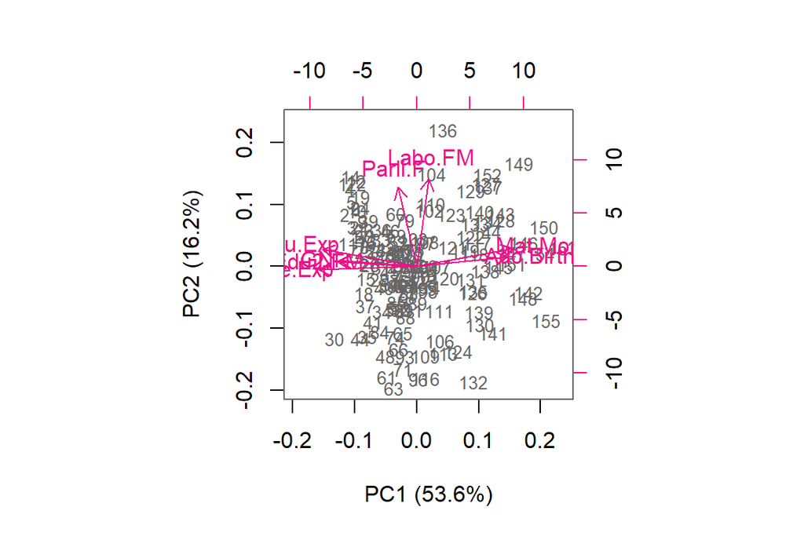

```r
# create object pc_lab to be used as axis labels
pc_lab <- paste0(names(pca_pr), " (", pca_pr, "%)")

# draw a biplot
biplot(pca_human_std, cex = c(0.8, 1), col = c("grey40", "deeppink2"), xlab = pc_lab[1], ylab = pc_lab[2])
```

With standardized data the PCA works a lot better. We can see that PC1 explains over 50% of the variance in the data. It consists of most of the variables in the data. In short it seems to show the economical standard of living in the country. The PC2 contributes to about 16% of the variance and represents variables Percetange of female representatives in parliament and Proportion of females in the labour force. The PC2 can be seen as the position of female in the country.